# week06_in_class

## Week 06

## Numpy

```python
import numpy as np
import matplotlib.pyplot as plt
```

Building block -> `arrays`

```python
numlist=[1,2,3]
numarray= np.array(numlist) # create array from list
print(numlist,numarray)
```

```
[1, 2, 3] [1 2 3]
```

```python
type(numlist)
```

```
list
```

```python
type(numarray)
```

```
numpy.ndarray
```

```python
numarray * 5
```

```
array([ 5, 10, 15])
```

```python
numlist*5
```

```
[1, 2, 3, 1, 2, 3, 1, 2, 3, 1, 2, 3, 1, 2, 3]
```

```python
numarray**5
```

```
array([  1,  32, 243], dtype=int32)
```

```python
print(numarray//2)
```

```
[0 1 1]
```

```python
x=np.array(range(1,7))
print(x)
```

```
[1 2 3 4 5 6]
```

`numpy` has its own version of the most common functions

```python
np.log(x)
```

```
array([0.        , 0.69314718, 1.09861229, 1.38629436, 1.60943791,
       1.79175947])
```

```python
import math as m
```

```python
m.log(x)
```

```
---------------------------------------------------------------------------
TypeError                                 Traceback (most recent call last)
<ipython-input-16-1507bd675c34> in <module>
----> 1 m.log(x)

TypeError: only size-1 arrays can be converted to Python scalars
```

You can still iterate on arrays, the same way you would do with lists

```python
for k in x:
    print(k)
```

```
1
2
3
4
5
6
```

You can still slice arrays, the same way you would slice lists

```python
x[::2]
```

[output not shown]

Arrays are mutable (like lists) and slicing will not produce a copy (unlike lists)

```python
y=x
y[0]=200
print(x,y)
```

```
[200   2   3   4   5   6] [200   2   3   4   5   6]
```

```python
z=x[:]
z[1] = 300
print(x,y,z)
```

```
[200 300   3   4   5   6] [200 300   3   4   5   6] [200 300   3   4   5   6]
```

```python
w = x.copy()
w[2] = 400

print(x,w)
```

```
[200 300   3   4   5   6] [200 300 400   4   5   6]
```

Summary

- their size cannot be changed after creation
- they can contain only objects of the same type
- can be sliced, and indexed as lists
- are mutable (like lists)
- slicing creates a 'view' of the array (not a new array)
- support vectorial operations (unlike lists)

## How to create an array

1. `np.array`

```python
mylist = [1,2,3,4,5,6,7,8,9]
myarray = np.array(mylist)
myarray
```

```
array([1, 2, 3, 4, 5, 6, 7, 8, 9])
```

1. `np.ones` or `np.zeros`

```python
x=np.ones(4)
x
```

```
array([1., 1., 1., 1.])
```

```python
y=np.zeros(5)
y
```

```
array([0., 0., 0., 0., 0.])
```

**Ex.** how do we create an array with 7 elements, all 4

```python
4*np.ones(7)
```

```
array([4., 4., 4., 4., 4., 4., 4.])
```

1. `np.empty` this will create an "empty" array (array of values not initialized. quicker than `np.zeros` and `np.ones` for large arrays)

```python
e = np.empty(6)
e
```

```
array([0.        , 0.69314718, 1.09861229, 1.38629436, 1.60943791,
       1.79175947])
```

1. `np.arange()` works exactly like range, but allows for not integer entries

```python
a=np.arange(0,4.5,0.5)
print(a)
```

```
[0.  0.5 1.  1.5 2.  2.5 3.  3.5 4. ]
```

```python
b=np.arange(-1.5,4.5)
print(b)
```

```
[-1.5 -0.5  0.5  1.5  2.5  3.5]
```

1. `np.linspace(s,e,p)` : `s`:starting point; `e`:end point; `p`: how many points

```python
np.linspace(0,10,11)
```

```
array([ 0.,  1.,  2.,  3.,  4.,  5.,  6.,  7.,  8.,  9., 10.])
```

```python
from time import time
```

```python
time()
```

```
1615227501.7924623
```

```python
startt = time()
y=[m.cos(k) for k in range(10**8)]
endt = time()
print(endt-startt)
```

```
58.47716546058655
```

```python
startt = time()
y=np.cos(np.arange(10**8))
endt= time()
print(endt-startt)
```

```
5.524827480316162
```

## `subplot`

`plt.subplot(r,c,p)`:

- `r`: number of rows
- `c`: number of columns
- `p`: position (starting at 1)

**ex.** produce a 3x2 subplot, $x\in [-\pi,\pi]$ use 101 points

- $y=\cos(x)$ in position 1, color blue
- $y=\sin(2x)$ in position 2, color green
- $y=0.5 x^2 -x +3$ in position 4, color magenta
- $y=\tan(x)$ in position 5, color yellow

post the image on discord, in the **subplot** channel

Use `plt.title()` for each subplot

Use `plt.suptitle()` for the major title which should be your **first, last name**

reminder `plt.subplots_adjust(wspace = ,hspace =)`

use `np.linspace` to generate $x$

```
plt.subplot(3,2,1)
plt.plot(x,y)
```

```
plt.subplot(3,2,2)
plt.plot(x,y)
```

## Project 3

```python
def f(x):
    return x**2 - 5 *x + 4

def fp(x):
    return 2*x - 5
```

```python
x=np.linspace(0,6,101)
```

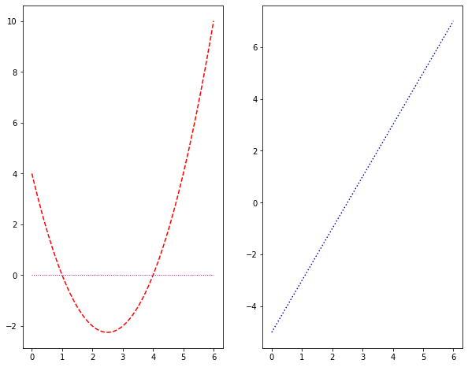

```python
plt.figure(figsize=(10,8))
plt.subplot(1,2,1)
plt.plot(x,f(x),'r--')
plt.plot([0,6],[0,0],'m:',linewidth = 1)
plt.subplot(1,2,2)
plt.plot(x,fp(x),'b:');
```

```python
def myfun(x,f):
    y=f(x)
    return y
```

```python
myfun(2,fp)
```

```
-1
```

```
def newton(x0,f,fp):
    ....
    return next iteration
```

```python
x=np.linspace(-1,1,11)
x
```

```
array([-1. , -0.8, -0.6, -0.4, -0.2,  0. ,  0.2,  0.4,  0.6,  0.8,  1. ])
```

```python
myfun(x,f)
```

```
array([10.  ,  8.64,  7.36,  6.16,  5.04,  4.  ,  3.04,  2.16,  1.36,
        0.64,  0.  ])
```

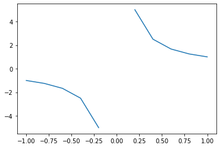

```python
plt.plot(x,1/x)
```

## Complex numbers

```python
z = complex(1,2) # real, imaginary part
z
```

```
(1+2j)
```

```python
z.real
```

```
1.0
```

```python
z.imag
```

```
2.0
```

```python
z**2
```

```
(-3+4j)
```

```python
myfun(z,f)
```

```
(-4-6j)
```

```python
r = np.linspace(-1,1,6)
i = np.linspace(complex(0,-1),complex(0,1),6)
```

```python
print(r,'\n\n',i)
```

```
[-1.  -0.6 -0.2  0.2  0.6  1. ]

 [0.-1.j  0.-0.6j 0.-0.2j 0.+0.2j 0.+0.6j 0.+1.j ]
```

```python
rr,ii = np.meshgrid(r,i)
print(rr,'\n\n',ii)
```

```
[[-1.  -0.6 -0.2  0.2  0.6  1. ]
 [-1.  -0.6 -0.2  0.2  0.6  1. ]
 [-1.  -0.6 -0.2  0.2  0.6  1. ]
 [-1.  -0.6 -0.2  0.2  0.6  1. ]
 [-1.  -0.6 -0.2  0.2  0.6  1. ]
 [-1.  -0.6 -0.2  0.2  0.6  1. ]]

 [[0.-1.j  0.-1.j  0.-1.j  0.-1.j  0.-1.j  0.-1.j ]
 [0.-0.6j 0.-0.6j 0.-0.6j 0.-0.6j 0.-0.6j 0.-0.6j]
 [0.-0.2j 0.-0.2j 0.-0.2j 0.-0.2j 0.-0.2j 0.-0.2j]
 [0.+0.2j 0.+0.2j 0.+0.2j 0.+0.2j 0.+0.2j 0.+0.2j]
 [0.+0.6j 0.+0.6j 0.+0.6j 0.+0.6j 0.+0.6j 0.+0.6j]
 [0.+1.j  0.+1.j  0.+1.j  0.+1.j  0.+1.j  0.+1.j ]]
```

```python
z=rr+ii

print(z)
```

```
[[-1. -1.j  -0.6-1.j  -0.2-1.j   0.2-1.j   0.6-1.j   1. -1.j ]
 [-1. -0.6j -0.6-0.6j -0.2-0.6j  0.2-0.6j  0.6-0.6j  1. -0.6j]
 [-1. -0.2j -0.6-0.2j -0.2-0.2j  0.2-0.2j  0.6-0.2j  1. -0.2j]
 [-1. +0.2j -0.6+0.2j -0.2+0.2j  0.2+0.2j  0.6+0.2j  1. +0.2j]
 [-1. +0.6j -0.6+0.6j -0.2+0.6j  0.2+0.6j  0.6+0.6j  1. +0.6j]
 [-1. +1.j  -0.6+1.j  -0.2+1.j   0.2+1.j   0.6+1.j   1. +1.j ]]
```

## Multidimensional array (`numpy`)

```python
a=np.linspace(1,12,12)
print(a)
```

```
[ 1.  2.  3.  4.  5.  6.  7.  8.  9. 10. 11. 12.]
```

```python
a.shape
```

```
(12,)
```

```python
b=a.reshape(3,4)
print(b)
```

```
[[ 1.  2.  3.  4.]
 [ 5.  6.  7.  8.]
 [ 9. 10. 11. 12.]]
```

```python
b.shape
```

```
(3, 4)
```

```python
c=a.reshape(6,-1)
print(c)
```

```
[[ 1.  2.]
 [ 3.  4.]
 [ 5.  6.]
 [ 7.  8.]
 [ 9. 10.]
 [11. 12.]]
```

```python
c.shape
```

```
(6, 2)
```

```python
a[5]
```

```
6.0
```

```python
b[1,1]
```

```
6.0
```

```python
b[1,1]=300
print(a,b,c)
```

```
[  1.   2.   3.   4.   5. 300.   7.   8.   9.  10.  11.  12.] [[  1.   2.   3.   4.]
 [  5. 300.   7.   8.]
 [  9.  10.  11.  12.]] [[  1.   2.]
 [  3.   4.]
 [  5. 300.]
 [  7.   8.]
 [  9.  10.]
 [ 11.  12.]]
```

```python
d=a.reshape(-1,3).copy()
d[1,2]=0
```

```python
print(d,a)
```

```
[[ 1.  2.  3.]
 [ 4.  5.  0.]
 [ 7.  8.  9.]
 [10. 11. 12.]] [  1.   2.   3.   4.   5. 300.   7.   8.   9.  10.  11.  12.]
```

`np.ones()`, `np.zeros()`, `np.empty()` still work

```python
e=np.ones((4,6))
e
```

```
array([[1., 1., 1., 1., 1., 1.],
       [1., 1., 1., 1., 1., 1.],
       [1., 1., 1., 1., 1., 1.],
       [1., 1., 1., 1., 1., 1.]])
```

## Operations

```python
a=np.arange(1,13).reshape(3,4)
a
```

```
array([[ 1,  2,  3,  4],
       [ 5,  6,  7,  8],
       [ 9, 10, 11, 12]])
```

```python
b=np.linspace(13,24,12).reshape(3,4)
b
```

```
array([[13., 14., 15., 16.],
       [17., 18., 19., 20.],
       [21., 22., 23., 24.]])
```

```python
a+b
```

```
array([[14., 16., 18., 20.],
       [22., 24., 26., 28.],
       [30., 32., 34., 36.]])
```

```python
a*b # element by element multiplication
```

```
array([[ 13.,  28.,  45.,  64.],
       [ 85., 108., 133., 160.],
       [189., 220., 253., 288.]])
```

matrix multiplication

```python
b.shape
```

```
(3, 4)
```

```python
c=np.arange(8).reshape(4,2)
c.shape
```

```
(4, 2)
```

```python
b@c
```

```
array([[184., 242.],
       [232., 306.],
       [280., 370.]])
```

```python
b.dot(c)
```

```
array([[184., 242.],
       [232., 306.],
       [280., 370.]])
```

```python
c.dot(b)
```

```
---------------------------------------------------------------------------
ValueError                                Traceback (most recent call last)
<ipython-input-58-c72b22f75651> in <module>
----> 1 c.dot(b)

ValueError: shapes (4,2) and (3,4) not aligned: 2 (dim 1) != 3 (dim 0)
```

```python
b
```

```
array([[13., 14., 15., 16.],
       [17., 18., 19., 20.],
       [21., 22., 23., 24.]])
```

```python
np.log(b)
```

```
array([[2.56494936, 2.63905733, 2.7080502 , 2.77258872],
       [2.83321334, 2.89037176, 2.94443898, 2.99573227],
       [3.04452244, 3.09104245, 3.13549422, 3.17805383]])
```

## slicing

```python
a=np.arange(40).reshape(5,8)
a
```

```
array([[ 0,  1,  2,  3,  4,  5,  6,  7],
       [ 8,  9, 10, 11, 12, 13, 14, 15],
       [16, 17, 18, 19, 20, 21, 22, 23],
       [24, 25, 26, 27, 28, 29, 30, 31],
       [32, 33, 34, 35, 36, 37, 38, 39]])
```

```python
a[1,:]
```

```
array([ 8,  9, 10, 11, 12, 13, 14, 15])
```

```python
a[1]
```

```
array([ 8,  9, 10, 11, 12, 13, 14, 15])
```

```python
a[:,4]
```

```
array([ 4, 12, 20, 28, 36])
```

```python
a[2:-1,:]
```

```
array([[16, 17, 18, 19, 20, 21, 22, 23],
       [24, 25, 26, 27, 28, 29, 30, 31]])
```

```python
a[::2,::2]
```

```
array([[ 0,  2,  4,  6],
       [16, 18, 20, 22],
       [32, 34, 36, 38]])
```

```python
a[::2,::2]=40
a
```

```
array([[40,  1, 40,  3, 40,  5, 40,  7],
       [ 8,  9, 10, 11, 12, 13, 14, 15],
       [40, 17, 40, 19, 40, 21, 40, 23],
       [24, 25, 26, 27, 28, 29, 30, 31],
       [40, 33, 40, 35, 40, 37, 40, 39]])
```

```python
y=np.linspace(1,10,10).reshape(5,2)
a[:,2:4]=y
a
```

```
array([[40,  1,  1,  2, 40,  5, 40,  7],
       [ 8,  9,  3,  4, 12, 13, 14, 15],
       [40, 17,  5,  6, 40, 21, 40, 23],
       [24, 25,  7,  8, 28, 29, 30, 31],
       [40, 33,  9, 10, 40, 37, 40, 39]])
```

```python
b=a.ravel()
b
```

```
array([40,  1,  1,  2, 40,  5, 40,  7,  8,  9,  3,  4, 12, 13, 14, 15, 40,
       17,  5,  6, 40, 21, 40, 23, 24, 25,  7,  8, 28, 29, 30, 31, 40, 33,
        9, 10, 40, 37, 40, 39])
```

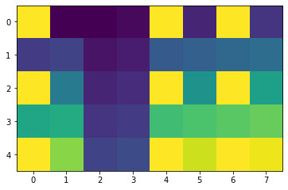

```python
plt.imshow(a);
```

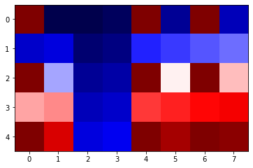

```python
plt.imshow(a,cmap='seismic');
```

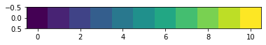

```python
x=np.linspace(0,1,11).reshape(1,11)
plt.imshow(x)
```